# Used Car Pricing in the Detroit 100-Mile Market

Author

Omar Hijazi

# 1 Introduction

This report analyzes used-car dealer listings within a 100-mile radius of Detroit, Michigan, collected from the MarketCheck Cars API free tier. The dataset includes four high-volume brands: Toyota, Honda, Ford, and Chevrolet. The analysis focuses on listing price, mileage, vehicle age, and key vehicle attributes such as body type, drivetrain, and transmission.

The goals of the project are to:

1. Identify which characteristics best predict listing price,
2. Determine whether the relationship between mileage and price differs by brand,
3. Test whether body type, drivetrain, and transmission still matter after controlling for mileage and age, and
4. Compare broad vehicle segments using body type as a proxy.

Because used-car listing prices are right-skewed, the analysis uses log(price) instead of raw price. This helps reduce the impact of unusually expensive listings, makes the model more stable, and lets the coefficients be interpreted roughly as percent changes in price.

# 2 Data & Preparation

The raw dataset contains **1777** observations and **27** variables. The main modeling variables include price, mileage, age, brand, body type, drivetrain, and transmission.

Next, the data is standardized for modeling. The preparation steps:

- keep valid values (`price > 0`, `miles >= 0`, `age >= 0`),
- convert key attributes into factors,
- lump rare categories to avoid fragmentation,
- set reference levels for interpretable comparisons, and
- create `log_price`.

Final Modeling Sample Summary

| Metric | Value |
| --- | --- |
| Final observations | 1777 |
| Number of brands | 4 |
| Minimum price | $1,950 |
| Maximum price | $109,995 |
| Minimum miles | 3 |
| Maximum miles | 365,037 |
| Minimum age | 0 |
| Maximum age | 31 |

# 3 Quick EDA

## 3.1 Log-transformed price distribution

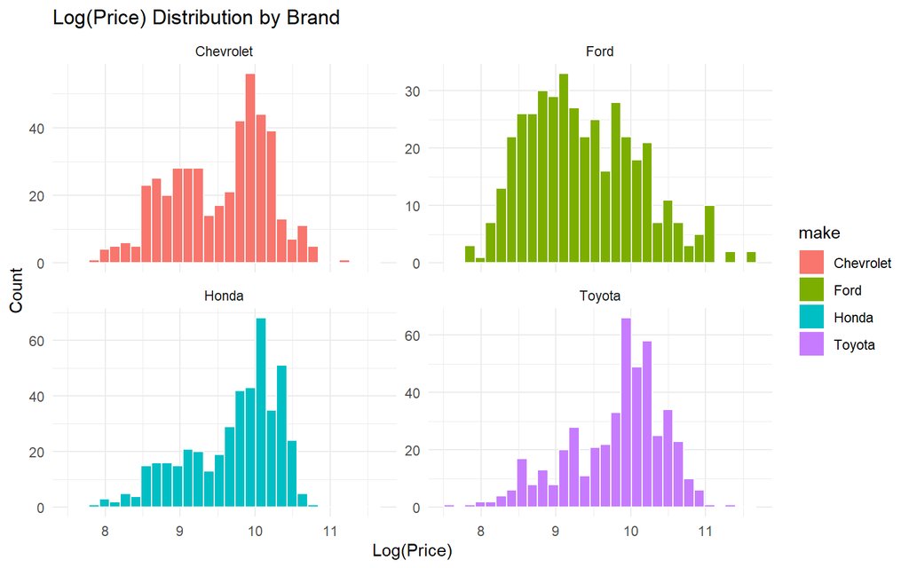

Compared with raw price, the log-transformed distribution is more balanced and works better for linear modeling. This supports using **log(price)** in the regression analysis.

## 3.2 Log(Price) vs Miles (by brand)

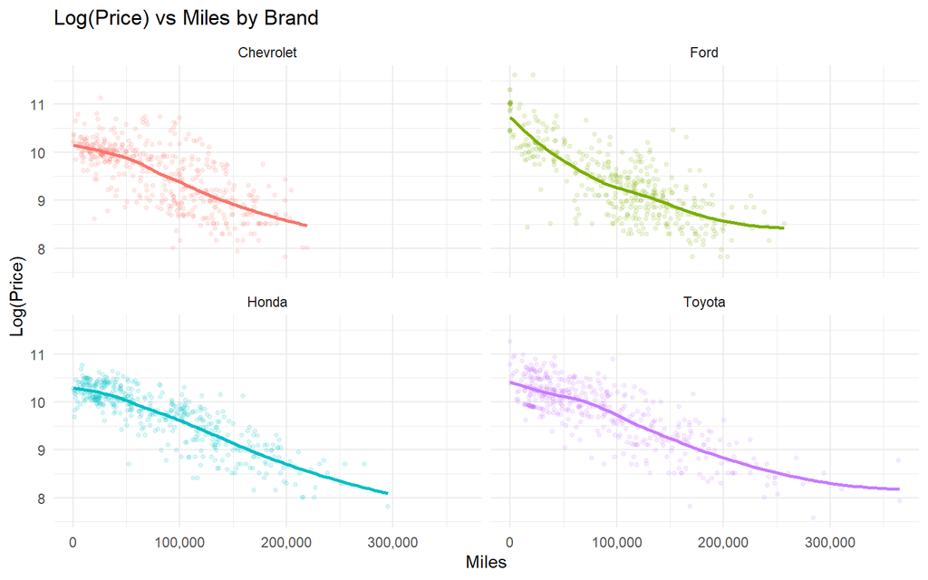

**log(price)** goes down as mileage increases, with prices dropping more sharply at lower mileage and then leveling off more at higher mileage. The separate brand trend lines also look different, suggesting that the relationship between mileage and price may vary by manufacturer.

## 3.3 Log(Price) vs Age (by brand)

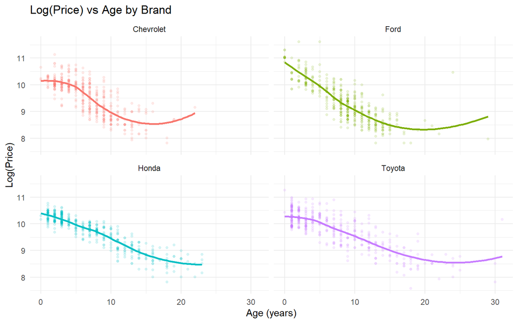

# 4 Q1. Which features best predict price?

The baseline model is:

**M1:** `log(price) ~ miles + age + make`

M1 — Estimated Percent Effects

| Effect | Percent_Change |
| --- | --- |
| Mileage (+10,000 miles) | -4.14 |
| Age (+1 year) | -6.43 |

**Answer (Q1).** In this model, mileage and age are the strongest predictors of listing price. In the baseline model, every additional **10,000 miles** is associated with about **4.14% lower** listing price, and each additional **year of age** is associated with about **6.43% lower** listing price, holding brand constant.

The brand indicators also show clear price differences after controlling for mileage and age. Compared with Chevrolet, both Honda and Toyota are priced higher on average, while Ford is closer to Chevrolet in this baseline model. Overall, the model fits the data well for a simple specification, with **Adjusted R² = 0.731**, showing that mileage, age, and brand explain a large share of the variation in listing prices.

# 5 Q2. Does the mileage-price relationship differ by brand?

To test value retention patterns, the next model allows the mileage slope to vary by brand:

**M2:** `log(price) ~ age + miles * make`

M2 — Mileage Effect by Brand (controls: age)

| make | percent_drop_per_10k_miles |
| --- | --- |
| Chevrolet | -4.75 |
| Ford | -5.81 |
| Honda | -3.31 |
| Toyota | -2.73 |

**Answer (Q2).** The relationship between mileage and price does differ by brand. Based on the estimated slopes, the price change for an additional 10,000 miles is:

- **Chevrolet:** -4.75%
- **Ford:** -5.81%
- **Honda:** -3.31%
- **Toyota:** -2.73%

A less negative value means the price drops more slowly for every additional 10,000 miles, which suggests better value retention. In this dataset, Toyota and Honda show slower mileage-related price declines than Ford and Chevrolet.

From a practical point of view, this suggests that buyers who care more about long-term value may see Toyota and Honda as better options at higher mileage, while Ford and Chevrolet may come with lower starting prices but lose value faster as mileage increases. Age also remains a strong negative predictor across all four brands, showing that both vehicle age and usage play an important role in lowering listing prices.

# 6 Q3. Do body type and drivetrain still matter after controlling for age and mileage?

The full-controls model is:

**M3:** `log(price) ~ miles + age + make + body_type + drivetrain + transmission`

Model Fit Comparison

| Model | N | Adjusted_R2 |
| --- | --- | --- |
| Baseline (M1) | 1777 | 0.731 |
| Interaction (M2) | 1777 | 0.743 |
| Full Controls (M3) | 1732 | 0.821 |

M3 — Coefficient Significance Table

| Predictor | Estimate | Std. Error | t-value | p-value | Sig. |
| --- | --- | --- | --- | --- | --- |
| miles | 0.0000 | 0.0000 | -20.474 | 0.0000 | *** |
| age | -0.0686 | 0.0024 | -28.175 | 0.0000 | *** |
| makeFord | -0.0467 | 0.0205 | -2.281 | 0.0227 | * |
| makeHonda | 0.2746 | 0.0227 | 12.073 | 0.0000 | *** |
| makeToyota | 0.3159 | 0.0212 | 14.887 | 0.0000 | *** |
| body_typeCar Van | 0.4314 | 0.1099 | 3.924 | 0.0001 | *** |
| body_typeCargo Van | 0.4125 | 0.1214 | 3.397 | 0.0007 | *** |
| body_typeCoupe | 0.5027 | 0.0834 | 6.030 | 0.0000 | *** |
| body_typeHatchback | -0.0055 | 0.0339 | -0.162 | 0.8710 | ns |
| body_typeMinivan | 0.2776 | 0.0364 | 7.625 | 0.0000 | *** |
| body_typePickup | 0.4858 | 0.0344 | 14.131 | 0.0000 | *** |
| body_typeSUV | 0.1663 | 0.0217 | 7.666 | 0.0000 | *** |
| body_typeOther | 0.3745 | 0.0891 | 4.204 | 0.0000 | *** |
| drivetrain4WD | 0.1780 | 0.0204 | 8.711 | 0.0000 | *** |
| drivetrainRWD | 0.1989 | 0.0666 | 2.986 | 0.0029 | ** |
| transmissionCVT | -0.0475 | 0.0216 | -2.201 | 0.0279 | * |
| transmissionManual | -0.0454 | 0.0574 | -0.791 | 0.4293 | ns |

The overall model is statistically significant (F(17, 1714) = 467.54, p < 0.0001), which shows that the predictors together explain a meaningful share of the variation in **log(price)** beyond random chance.

Looking at the individual predictors, **mileage** and **age** are highly significant (p < 0.001), confirming that they are the main drivers of price. The **brand indicators** for Honda and Toyota are also significant, showing clear price premiums over Chevrolet after controlling for the other variables. Among the vehicle features, **SUV and Pickup body types** and **4WD/RWD drivetrains** have significant positive coefficients, which supports the idea that vehicle configuration still matters even after accounting for age and mileage. Transmission effects are weaker and less consistently significant than the other vehicle features.

**Answer (Q3).** Adding body type, drivetrain, and transmission improves the model’s explanatory power. Adjusted R² increases from **0.731** in M1 to **0.821** in M3. This suggests that vehicle configuration adds useful information beyond age, mileage, and brand.

Interpreting the main patterns in M3 relative to the reference categories (Sedan, FWD, Automatic, Chevrolet):

- **SUVs and Pickups** show price premiums relative to Sedans.
- **4WD** and **RWD** show price premiums relative to FWD.
- Transmission effects are smaller. CVT appears somewhat lower than Automatic, while Manual is not consistently different and may be influenced by sample size.

Overall, the full model supports the conclusion that vehicle features still play an important role in explaining price, even after controlling for age, mileage, and brand.

# 7 Q4. Segment differences (body type proxy)

As a descriptive comparison of segments, the following chart shows median prices by body type and brand for groups with sufficient sample size.

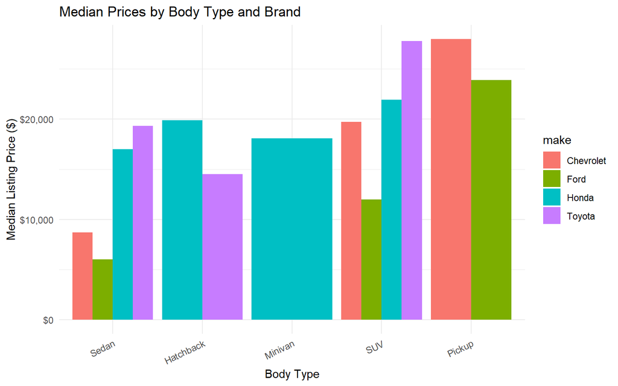

**Answer (Q4).** The descriptive summary shows clear differences across vehicle segments. SUVs and pickups tend to have higher median listing prices than sedans, which likely reflects differences in vehicle type and market demand. These differences are not only descriptive. In M3, body type still matters after controlling for mileage, age, and brand, suggesting that segment-level price differences remain even when comparing vehicles with similar age and mileage.

# 8 Diagnostics

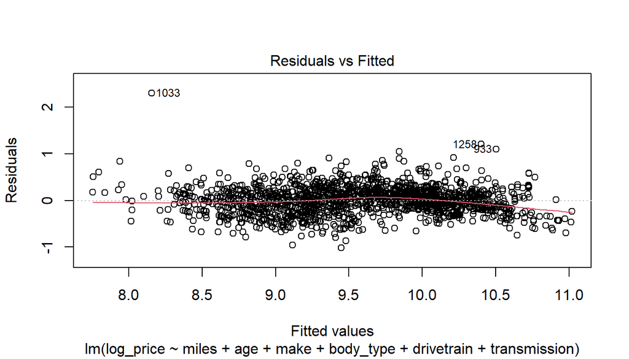

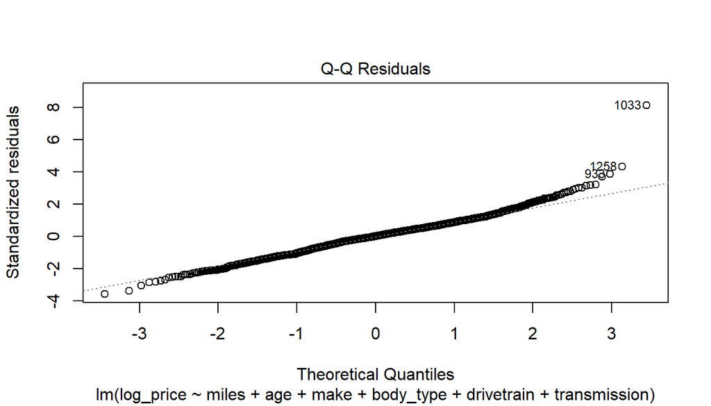

The **Normal Q-Q plot** stays fairly close to the line in the middle, but there are some noticeable differences in the tails and a few outliers. This suggests the residuals are not perfectly normal, though the overall pattern is still acceptable for this kind of applied pricing analysis.

M3 — Variance Inflation Factors

| Predictor | VIF | Flag |
| --- | --- | --- |
| miles | 2.90 | OK |
| age | 3.07 | OK |
| make | 1.20 | OK |
| body_type | 1.29 | OK |
| drivetrain | 2.28 | OK |
| transmission | 1.40 | OK |

VIF values below 5 suggest there is no serious multicollinearity among the predictors. Age and mileage are naturally somewhat related, but they still stay within an acceptable range. Since no predictor has a VIF above 10, multicollinearity does not appear to be a major issue in M3.

Overall, the diagnostics suggest that M3 is a reasonable model to use for interpretation in this context.

# 9 Data & API Notes

The listings were collected using the free tier of the MarketCheck Cars API. Since the free plan limits how many rows can be returned per query, the dataset was built by pulling each brand separately and then removing duplicates based on listing ID. The data reflects dealer asking prices at one point in time, not final sale prices.

# 10 Limitations

- **Listings are not transactions:** asking prices may be different from the final sale prices.
- **Snapshot bias:** the results only reflect the inventory that was available during the data collection period.
- **Incomplete vehicle details:** trim and option information is not always fully available, so body type and drivetrain are used as broader proxies.
- **Regional scope:** the results are specific to the Detroit 100-mile market and the four brands included in the analysis.

# 11 Key Findings

- **Mileage and age are the strongest predictors** of used-car listing prices in the Detroit market.
- **Brand differences matter:** in this dataset, Toyota and Honda show slower mileage-related price declines than Ford and Chevrolet.
- **Vehicle configuration still matters:** SUVs, pickups, and 4WD and RWD drivetrains tend to have price premiums even after controlling for age, mileage, and brand.
- **Segment differences are consistent:** SUVs and pickups are generally priced higher than sedans, both in the descriptive summary and in the regression results.

# 12 Conclusion

This analysis shows that used car prices in the Detroit 100-mile market are mainly affected by mileage, age, brand, and vehicle features. In this sample, Toyota and Honda seem to hold their value better as mileage goes up compared to Ford and Chevrolet. SUVs, pickups, and some drivetrain types also tend to have higher listing prices. Because prices were right-skewed, using **log(price)** made the regression model more stable and easier to interpret. Overall, the results show that both depreciation factors and vehicle characteristics help explain dealer listing prices in this market.